# An introduction to the TENxMultiomeTools package

Dario Righelli

2022-09-14

# 1 Requirements

```r
library(TENxMultiomeTools)
library(AllenInstituteBrainData)
library(Signac)
library(Seurat)
library(EnsDb.Mmusculus.v79)
library(scuttle)
library(scater)
```

# 2 Introduction

The `TENxMultiomeTools` package is a work in progress project intended to facilitate the loading and handling of 10x Genomics multiome data in `SingleCellExperiment` format.

This pipeline starts from the output generated by the 10x cellranger-ARC pipeline and sis designed for differential analysis of multiple samples in different conditions. We defined it while working on a complex design of 12 different multiome samples of mouse brain cortex in 4 different condition.

Because the data are not published yet, we are using one of the publicly available dataset from the official 10x Genomics website to illustrate the available functionalities of the package and challanges faced with this type of data.

Additionally, because of lack of public datasets with different conditions, we cannot illustrate the full pipeline, but we’ll go through the implemented functionalities and we’ll illustrate possible examples on real data.

# 3 Loading Data

To facilitate 10x Genomics Multiome data loading we can use the `read10xMultiome` function, which takes the following parameters as input:

- `sample_path`: the path of the experiment
- `type`: the type of data to load, sparse/hdf5
- `data`: data type to load, filtered/raw
- `compressed`: logical indicating if the data are stored in a compressed format
- `col.names`: logical indicating if to add ID to the cols of the assays.
- `addfrags`: logical indicating if the path to the fragments file has to be saved in the sce. Note that this is needed when computing the metrics in the next step.
- `reference`: character indicating the reference assay to use as main assay

This function loads the data in a `SingleCellExperiment` format, creating a `main` assay and an `altExp` assay, which is another `SingleCellExperiment` object. The `colData` of the main assay will always contain the information related to the cells of the experiment, so it will not be replicated twice, but only stored in the main one. On the other hand the information related to the rows of the assays differ because for the RNA a `rowData` `DataFrame` stores information about the genes, while for the ATAC data it will be in a `rowRanges` format. This format allows to store the information about the peaks in a `GenomicRanges` format where the genomic coordinates are in the form of Chromosome, Start and End while additional data are stored in the `mcols` `DataFrame.`

```r
path="multiome_website_mouse_old/outs/"
sce <- read10xMultiome(
    sample.path=path,
    type="sparse",
    data="filtered",
    compressed=TRUE,
    col.names=TRUE,
    addfrags=TRUE,
    reference="RNA")
sce
```

```
## class: SingleCellExperiment
## dim: 32285 4878
## metadata(0):
## assays(1): counts
## rownames(32285): ENSMUSG00000051951 ENSMUSG00000089699 ...
##   ENSMUSG00000095019 ENSMUSG00000095041
## rowData names(6): ID Symbol ... Start End
## colnames: NULL
## colData names(2): Sample Barcode
## reducedDimNames(0):
## mainExpName: RNA
## altExpNames(1): ATAC
```

```r
colData(sce)
```

```
## DataFrame with 4878 rows and 2 columns
##                      Sample            Barcode
##                 <character>        <character>
## 1    multiome_website_mou.. AAACAGCCAACCGCCA-1
## 2    multiome_website_mou.. AAACAGCCAAGGTCGA-1
## 3    multiome_website_mou.. AAACAGCCAGGAACAT-1
## 4    multiome_website_mou.. AAACAGCCATATTGAC-1
## 5    multiome_website_mou.. AAACAGCCATCAGCAC-1
## ...                     ...                ...
## 4874 multiome_website_mou.. TTTGTGGCATTTGCTC-1
## 4875 multiome_website_mou.. TTTGTGTTCAATGACC-1
## 4876 multiome_website_mou.. TTTGTTGGTAGACAAA-1
## 4877 multiome_website_mou.. TTTGTTGGTGGAGCAA-1
## 4878 multiome_website_mou.. TTTGTTGGTTAGAGCC-1
```

```r
rowData(sce)
```

```
## DataFrame with 32285 rows and 6 columns
##                                    ID      Symbol            Type         Chr
##                           <character> <character>     <character> <character>
## ENSMUSG00000051951 ENSMUSG00000051951        Xkr4 Gene Expression        chr1
## ENSMUSG00000089699 ENSMUSG00000089699      Gm1992 Gene Expression        chr1
## ENSMUSG00000102331 ENSMUSG00000102331     Gm19938 Gene Expression        chr1
## ENSMUSG00000102343 ENSMUSG00000102343     Gm37381 Gene Expression        chr1
## ENSMUSG00000025900 ENSMUSG00000025900         Rp1 Gene Expression        chr1
## ...                               ...         ...             ...         ...
## ENSMUSG00000095523 ENSMUSG00000095523  AC124606.1 Gene Expression  JH584299.1
## ENSMUSG00000095475 ENSMUSG00000095475  AC133095.2 Gene Expression  JH584299.1
## ENSMUSG00000094855 ENSMUSG00000094855  AC133095.1 Gene Expression  JH584299.1
## ENSMUSG00000095019 ENSMUSG00000095019  AC234645.1 Gene Expression  JH584303.1
## ENSMUSG00000095041 ENSMUSG00000095041  AC149090.1 Gene Expression  JH584304.1
##                        Start       End
##                    <numeric> <numeric>
## ENSMUSG00000051951   3671497   3671498
## ENSMUSG00000089699   3466586   3466587
## ENSMUSG00000102331   3658903   3658904
## ENSMUSG00000102343   3985983   3986215
## ENSMUSG00000025900   4360313   4409241
## ...                      ...       ...
## ENSMUSG00000095523    837363    837364
## ENSMUSG00000095475    913082    913083
## ENSMUSG00000094855    921941    921942
## ENSMUSG00000095019     81606     81607
## ENSMUSG00000095041     59666     59690
```

```r
altExp(sce)
```

```
## class: SingleCellExperiment
## dim: 172193 4878
## metadata(1): fragpath
## assays(1): counts
## rownames(172193): chr1:3060610-3061485 chr1:3094582-3095477 ...
##   JH584292.1:12506-13421 JH584295.1:1378-1976
## rowData names(3): ID Symbol Type
## colnames: NULL
## colData names(2): Sample Barcode
## reducedDimNames(0):
## mainExpName: NULL
## altExpNames(0):
```

```r
rowRanges(altExp(sce))
```

```
## GRanges object with 172193 ranges and 3 metadata columns:
##                            seqnames          ranges strand |
##                               <Rle>       <IRanges>  <Rle> |
##     chr1:3060610-3061485       chr1 3060610-3061485      * |
##     chr1:3094582-3095477       chr1 3094582-3095477      * |
##     chr1:3113326-3114208       chr1 3113326-3114208      * |
##     chr1:3119674-3120516       chr1 3119674-3120516      * |
##     chr1:3121300-3122029       chr1 3121300-3122029      * |
##                      ...        ...             ...    ... .
##   GL456216.1:41132-41904 GL456216.1     41132-41904      * |
##   GL456216.1:43950-44762 GL456216.1     43950-44762      * |
##   GL456216.1:48736-49596 GL456216.1     48736-49596      * |
##   JH584292.1:12506-13421 JH584292.1     12506-13421      * |
##     JH584295.1:1378-1976 JH584295.1       1378-1976      * |
##                                              ID                 Symbol
##                                     <character>            <character>
##     chr1:3060610-3061485   chr1:3060610-3061485   chr1:3060610-3061485
##     chr1:3094582-3095477   chr1:3094582-3095477   chr1:3094582-3095477
##     chr1:3113326-3114208   chr1:3113326-3114208   chr1:3113326-3114208
##     chr1:3119674-3120516   chr1:3119674-3120516   chr1:3119674-3120516
##     chr1:3121300-3122029   chr1:3121300-3122029   chr1:3121300-3122029
##                      ...                    ...                    ...
##   GL456216.1:41132-41904 GL456216.1:41132-41904 GL456216.1:41132-41904
##   GL456216.1:43950-44762 GL456216.1:43950-44762 GL456216.1:43950-44762
##   GL456216.1:48736-49596 GL456216.1:48736-49596 GL456216.1:48736-49596
##   JH584292.1:12506-13421 JH584292.1:12506-13421 JH584292.1:12506-13421
##     JH584295.1:1378-1976   JH584295.1:1378-1976   JH584295.1:1378-1976
##                                 Type
##                          <character>
##     chr1:3060610-3061485       Peaks
##     chr1:3094582-3095477       Peaks
##     chr1:3113326-3114208       Peaks
##     chr1:3119674-3120516       Peaks
##     chr1:3121300-3122029       Peaks
##                      ...         ...
##   GL456216.1:41132-41904       Peaks
##   GL456216.1:43950-44762       Peaks
##   GL456216.1:48736-49596       Peaks
##   JH584292.1:12506-13421       Peaks
##     JH584295.1:1378-1976       Peaks
##   -------
##   seqinfo: 26 sequences from an unspecified genome; no seqlengths
```

# 4 Create Annotation

The 10x Multiome default output comes with an `annotation` file for the detected genes, but this file could be very heavy to store in memory and to manipulate. A way to avoid this is to create an annotation by aid of an EnsDb package, which downloads the annotation data for an entire genome.

```r
ensdb <- EnsDb.Mmusculus.v79
seqlevelsStyle(ensdb) <- "UCSC"
annotation <- GetGRangesFromEnsDb(ensdb = ensdb)
genome(annotation) <- "mm10"
```

# 5 Quality Control

Once that we have the data loaded and an annotation object in GenomicRanges format, we can start by computing some quality control metrics.

At the moment we defined three quality controls approaches, the Signac metrics, the `scuttle::isOutlier` and the doublets detection implemented in the `scDblFinder` package, but we’ll focus on the Signac metrics for this tutorial.

## 5.1 Signac Metrics

At the moment we implemented a wrapper for the Signac package (available on CRAN), which allows to compute multiple metrics both on RNA and ATAC data.

The metrics computed by Signac are defined as follows:

- number of counts per each gene for the RNA and each feature for the ATAC
- the number of features on the RNA
- computing the ratio of fragments between 147 bp and 294 bp (mononucleosome) to fragments < 147 bp (nucleosome-free)
- computing the TSS enrichment score as defined by *Encode*: ++ normalized score on the number of reads around (2000bp up/down) the TSS

```r
sce <- computeSignacMetrics(sce, annotation)
```

```
## Computing hash
```

```
## Extracting TSS positions
```

```
## Extracting fragments at TSSs
```

```
##
## Computing TSS enrichment score
```

## 5.2 Compute filters on the previous metrics

Once we have the `Signac` metrics computed, we can use them to filter-out low-quality cells. To do so, we decided to compute the quantiles of the distribution of each metric.

We defined the low-quality cells as the ones that have at the same time all these checks passed: + number of counts per genes and features lower than the lowest quantile (default 5%) and higher than the highest quantile (default 95%). + number of features on the RNA lower than the lowest quantile (default 5%) and higher than the highest quantile(default 95%). + nucleosome signal lower than 2 + TSS enrichment lower that 1

We can choose this thresholds by hand with the `lowQuantThr`, `highQuantThr`, `nucleosomeThr` and `TSSThr`, parameters in the `computeFilterCellsMetrics` function.

Of course the default parameters can be chosen with an heuristic approach.

```r
sce <- computeFilterCellsMetrics(sce, metric="quantile",
    lowQuantThr="5%", highQuantThr="90%",
    nucleosomeThr=2, TSSThr=1)
```

## 5.3 Quality Control Plots

We can take a look to the distributions and the labeled cells with the `plotFilteredCells` function, which shows violin plots for all the metrics computed and colors the cells based on the quality control passed/not passed label.

The arguments of this function allow to plot the filtered-in/out cells with the `inout` parameter. Of course we are mainly interested in the filtered-out cells because we want to better understand if there is something important the we’re filtering out.

It is also possible to pass a custom column with a user-defined column name with `TRUE`/`FALSE` values indicating the kept/filtered cells, by aid of the `filterCellsBy` and `customColName` parameters.

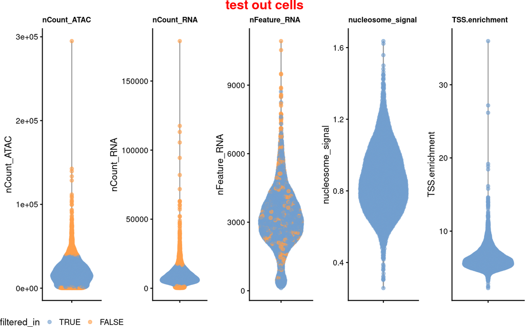

```r
plotFilteredCells(sce, name="test", inout="out")
```

## 5.4 Doublets

Another Quality Control on the cells can be done by computing doublets scores. We implemented a wrapper on the `scDblFinder` package, because it offers multiple methods for doublets detection. In particular, the doublet score for each cell is based on the density of simulated doublets around it.

Even if the results provided by this package are still under verification, we suggest to use it to better understand the quality of the cells in the experiment.

Actually, we implemented the method for the scRNAseq data, but further implementations will take into account methods for scATACseq data and further investigations need to be done on how to apply these methods on both assays.

```r
sce <- logNormCounts(sce)
sce <- computeDoublets(sce, method="griffiths")
```

It is possible to visualize these results with a simple TSNE plot, but better investigations can be done when cell types labels will be assigned to our cell and looking where the doublets fall in our dataset.

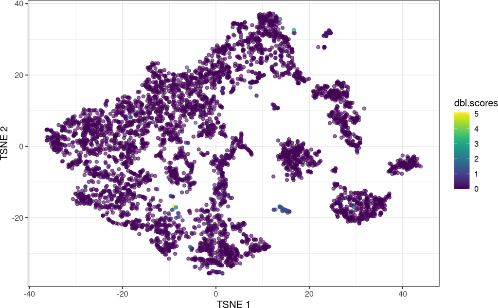

```r
sce <- runPCA(sce, ntop=length(rownames(sce)))
sce <- runTSNE(sce, dimred="PCA")
plotTSNE(sce, colour_by="dbl.scores") + theme_bw()
```

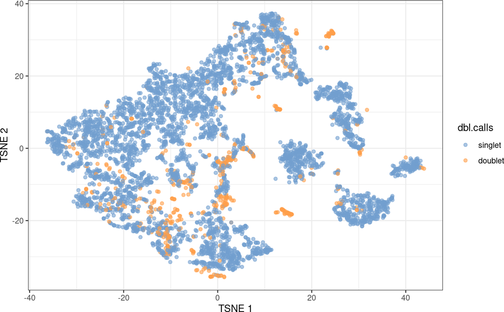

```r
plotTSNE(sce, colour_by="dbl.calls") + theme_bw()
```

## 5.5 Filtering Cells

Once we retain satisfied with the Quality Controls we can proceed by filtering the cells and to normalize the data.

We highlight that the `in_signac` column is automatically computed in the `computeFilterCellsMetrics` and it is a logical `AND` across all the metrics described in the previous “Signac” steps.

```r
sce <- sce[,sce$in_signac]
sce <- logNormCounts(sce)
sce <- runPCA(sce, ntop=length(rownames(sce)))
sce <- runTSNE(sce, dimred="PCA")
```

# 6 Assign Cell Labels

To assign cell labels there are several methods available in literature, some of which requires a reference dataset which helps to map the cell labels from the reference to our dataset.

At the moment there are not so many reliable reference dataset easisly available, in particular with validated cell types and, obviously, not for any kind of tissue we could need.

## 6.1 Cell Types Reference

For this tutorial, we are using a reference dataset from the Allen Institute, available from the `AllenInstituteBrainData` package https://github.com/drighelli/AllenInstituteBrainData which allows to download an annotated dataset of ~1 Million mouse brain cells annotated at three different levels of taxonomy.

This reference has three levels of annotation graularity:

- the cluster level is the level where the cells have been clustered in
- the subclass level is the level where the cells have been validated thank to cell-type markers
- the class level is the level where the cells have been grouped together because of cell-types belonging to the same cell family.

After downloading the dataset, it could be useful to create pseudo-bulk counts to speed up our computations. Using a reference of 1 Million cells could take very long time during the process of cell type annotation, and from our tests using the pseudo-bulk counts is a pretty good approximation in terms of the obtained results.

```r
allen <- AllenInstituteBrainData("Allen_Mouse_2020")
allen <- aggregateAcrossCells(allen, use.assay.type = "counts",id=DataFrame(label=allen$subclass_label))
allen <- logNormCounts(allen)
```

We need to map the annotation in the same gene format as our dataset to compute the cell labels in the next step.

```r
allen <- readRDS("allen_pseudo.RDS")
rownames(allen) <- rowData(allen)$X
symbol_allen <- rownames(allen)
map <- mapIds(EnsDb.Mmusculus.v79, keys= symbol_allen, keytype = "SYMBOL",
        column = "GENEID")
stopifnot(length(map) == nrow(allen))
rowData(allen)$symbol <- symbol_allen
rowData(allen)$ens <- map
allen <- allen[!is.na(rowData(allen)$ens),]
rownames(allen) <- rowData(allen)$ens
```

## 6.2 Assigning labels to the cells

At this point we can simply assign the labels from the reference to our dataset. At the moment, we created a wrapper `assignLabels` around the `SingleR` package, but, as already mentioned, there is plenty of methods that can be used for this scope.

Indeed, further versions of this function will implement other methods, i.e. `Azimuth` from Rahul Satija lab.

```r
allen <- logNormCounts(allen)
sce <- assignLabels(sce, allen, "subclass_label")
colData(sce)
```

```
## DataFrame with 3577 rows and 21 columns
##                                    Sample            Barcode    orig.ident
##                               <character>        <character>      <factor>
## AAACAGCCAACCGCCA-1 multiome_website_mou.. AAACAGCCAACCGCCA-1 SeuratProject
## AAACAGCCAAGGTCGA-1 multiome_website_mou.. AAACAGCCAAGGTCGA-1 SeuratProject
## AAACAGCCATATTGAC-1 multiome_website_mou.. AAACAGCCATATTGAC-1 SeuratProject
## AAACAGCCATGGTTAT-1 multiome_website_mou.. AAACAGCCATGGTTAT-1 SeuratProject
## AAACATGCACTTACAG-1 multiome_website_mou.. AAACATGCACTTACAG-1 SeuratProject
## ...                                   ...                ...           ...
## TTTGTGGCACTCAACA-1 multiome_website_mou.. TTTGTGGCACTCAACA-1 SeuratProject
## TTTGTGGCATTTGCTC-1 multiome_website_mou.. TTTGTGGCATTTGCTC-1 SeuratProject
## TTTGTTGGTAGACAAA-1 multiome_website_mou.. TTTGTTGGTAGACAAA-1 SeuratProject
## TTTGTTGGTGGAGCAA-1 multiome_website_mou.. TTTGTTGGTGGAGCAA-1 SeuratProject
## TTTGTTGGTTAGAGCC-1 multiome_website_mou.. TTTGTTGGTTAGAGCC-1 SeuratProject
##                    nCount_RNA nFeature_RNA nCount_ATAC nFeature_ATAC
##                     <numeric>    <integer>   <numeric>     <integer>
## AAACAGCCAACCGCCA-1      14702         4382       22215          9875
## AAACAGCCAAGGTCGA-1       5916         2814       12253          6001
## AAACAGCCATATTGAC-1       8938         2938       26547         11317
## AAACAGCCATGGTTAT-1       9332         3487       31227         13427
## AAACATGCACTTACAG-1       9595         3550       32771         14454
## ...                       ...          ...         ...           ...
## TTTGTGGCACTCAACA-1       3354         1805       28801         12195
## TTTGTGGCATTTGCTC-1      11406         3799       10823          5247
## TTTGTTGGTAGACAAA-1       6280         2722       22004          9368
## TTTGTTGGTGGAGCAA-1      12540         4054       12754          6043
## TTTGTTGGTTAGAGCC-1       5300         2268       20655          9068
##                    nucleosome_signal nucleosome_percentile TSS.enrichment
##                            <numeric>             <numeric>      <numeric>
## AAACAGCCAACCGCCA-1          0.874878                  0.56        5.36800
## AAACAGCCAAGGTCGA-1          0.707787                  0.21        5.39927
## AAACAGCCATATTGAC-1          0.989265                  0.76        6.28288
## AAACAGCCATGGTTAT-1          1.205687                  0.97        5.07396
## AAACATGCACTTACAG-1          1.017127                  0.81        5.32518
## ...                              ...                   ...            ...
## TTTGTGGCACTCAACA-1          0.651811                  0.11        5.41289
## TTTGTGGCATTTGCTC-1          0.716490                  0.22        7.23337
## TTTGTTGGTAGACAAA-1          1.273696                  0.99        5.67654
## TTTGTTGGTGGAGCAA-1          1.057762                  0.86        5.60341
## TTTGTTGGTTAGAGCC-1          1.015403                  0.80        6.85468
```

[output cut: 24 more lines]

```
## TTTGTTGGTGGAGCAA-1                TRUE              TRUE       TRUE      TRUE
## TTTGTTGGTTAGAGCC-1                TRUE              TRUE       TRUE      TRUE
##                    sizeFactor dbl.calls dbl.scores     SingleR
##                     <numeric>  <factor>  <numeric> <character>
## AAACAGCCAACCGCCA-1   1.768287   singlet   0.019512          CR
## AAACAGCCAAGGTCGA-1   0.711548   singlet   0.019512       Astro
## AAACAGCCATATTGAC-1   1.075020   singlet   0.029268      NP PPP
## AAACAGCCATGGTTAT-1   1.122409   singlet   0.068292          CR
## AAACATGCACTTACAG-1   1.154041   singlet   0.009756          CR
## ...                       ...       ...        ...         ...
## TTTGTGGCACTCAACA-1   0.403403   singlet   0.009756       Astro
## TTTGTGGCATTTGCTC-1   1.371860   singlet   0.029268          CR
## TTTGTTGGTAGACAAA-1   0.755329   singlet   0.019512   Sst Chodl
## TTTGTTGGTGGAGCAA-1   1.508252   singlet   0.097560 L2/3 IT RHP
## TTTGTTGGTTAGAGCC-1   0.637459   singlet   0.019512       IG-FC
```

```r
head(sce$SingleR)
```

```
## [1] "CR"        "Astro"     "NP PPP"    "CR"        "CR"        "Sst Chodl"
```

# 7 Visualizing cell types

Once we have the cell types labeled for our experiment, we are interested in understanding their clustering and this can be easily done with the `plotTSNE` function of the `scater` package.

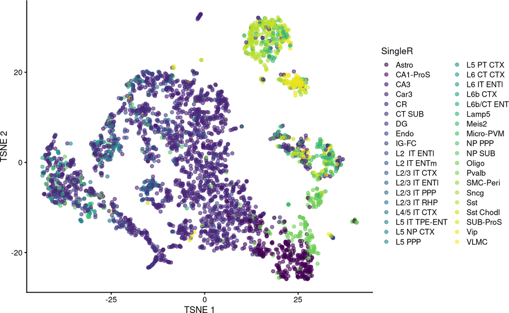

```r
plotTSNE(sce, colour_by="SingleR")
```

# 8 Differential Analysis

We selected two main approaches for doing differential analysis of these data, by applying muscat (working on single cell data) and by using edgeR (working on bulk data).

Because the second one produced better results on our datasets, we are going to illustrate the steps that can be performed to apply edgeR on single cell data to obtain differentially expressed genes (RNA) and differential accessible regions (ATAC).

To apply bulk analysis methods on single cell data, these need to be transformed in pseudo-bulk counts, and to do so there are multiple methods able to do that.

NB: We are not pointing to not use muscat (or other methods), but to always compare the results produced by multiple approaches to better investigate your data.

## 8.1 Pseudobulk

A possible approach to obtain pseudo-bulk data from your single-cell is to use the `aggregateAcrossCells` method from the `scuttle` package (as previously done for the reference dataset).

To apply this method we simply have to define a named vector of the cell types to use for the aggregation of the cells. In our case, we saved this information in the `colData` of our `SingleCellExperiment` under the `SingleR` column.

This approach is pretty straightforward when working with a scRNAseq because the genes are well defined even when working with multiple experiments.

In the end, we will have a new `SingleCellExperiment` with a reduced number of columns, which, in turn, will be of the same number of cell types defined in our `SingleR` `colData` column.

```r
sce_pseudo <- aggregateAcrossCells(sce, use.assay.type="counts",
        id=DataFrame(label=sce$SingleR))
```

At this point it is possible to apply and visualize the data like bulk data.

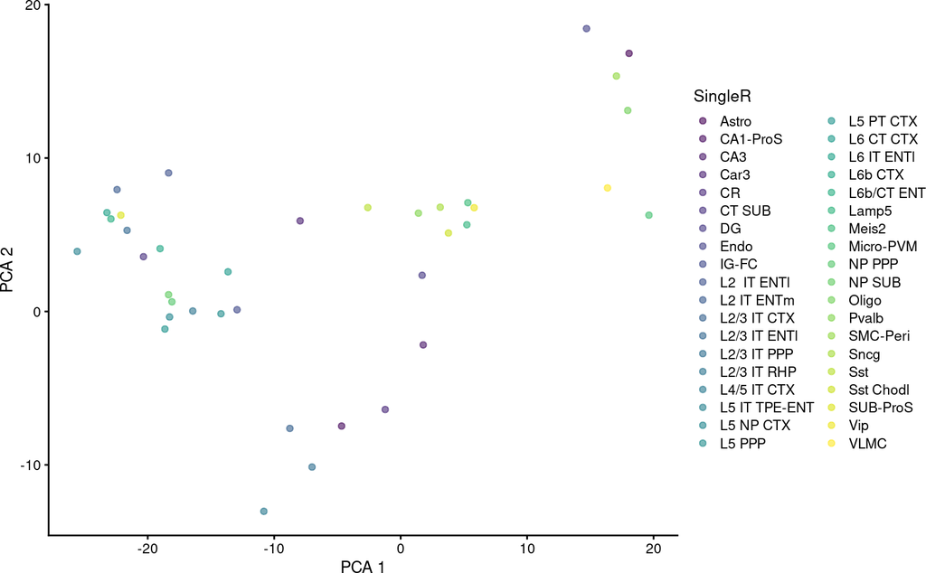

```r
plotPCA(sce_pseudo, colour_by="SingleR")
```

The same operation can be made on a single ATAC experiment obtaining the same number of columns as for the RNA.

```r
sce_pseudo_atac <- aggregateAcrossCells(altExp(sce), use.assay.type="counts",
        id=DataFrame(label=sce$SingleR))
altExp(sce_pseudo) <- sce_pseudo_atac
```

But things become a little bit more complicated when having multiple ATAC experiments, coming from different conditions, it could be problematic to compute a pseudo-bulk counts, because of the differences across the peaks (each experiment has different number of peaks and coordinates).

At the moment, to provide a solution to this issue, we are implementing (still needing some bug fixing and testing) a solution to this problem by adapting the `finalRegions` function present in the `DEScan2` package, which will return a new `SingleCellExperiment` object with the pseudod-count matrix computed on the multiple experiments.

Additionally, both previous operations on a single experiment can be made with our wrapper `computePseudoBulk` in a unique instruction that computes pseudo-bulk counts both for RNA and ATAC assays.

```r
sce_pseudo <- computePseudoBulk(sce, ctCol="SingleR")
```

At this point, it is easy to apply standard bulk pipelines to obtain differentially expressed genes and differentially accessible regions, per each cell type across different conditions.

Like applying normalization, PCA, gene-filtering and classical differential approaches like `edgeR` and `DESeq2`.

# 9 Create and export tracks

In order to visualize tracks for a specific cell type in the *UCSC Genome Browser* we implemented a function which takes care to export our data in *BigWig* format. To do so, the function needs some external software and the path to the original bam files of the experiment.

In particular it uses the following tools:

- `sinto`: a python software to create bam files per each cell type starting from a list of barcodes (the ones of the specified cell type)
- `samtools`: useful to sort and index the new bam files
- `deeptools` bamCoverage: to create bigwig files of the freshly created bam files

Once we have the *BigWig* files, we can easily create a new session in the *UCSC Genome Browser* and upload them to inspect them.

Further implementation of this function will try to avoid as much external tools as possible, possibly by aid of the `rtracklayer` package, and automatically create a session with the desired tracks.

```r
createTracks(sce, cellTypesCol="SingleR", cellType="CR", bamdir=path,
    outdir=path, ncores=10)
```